# Coursera Machine Learning Peer Reviewed Assignment (week 4)

Elisabeth van der Meijde

5 januari 2018

```r
require("caret")
require("rpart")
require("tidyverse")
require("knitr")
require("rattle")
require("doParallel")
set.seed(1024)
```

## Introduction

### Background

Using devices such as Jawbone Up, Nike FuelBand, and Fitbit it is now possible to collect a large amount of data about personal activity relatively inexpensively. These type of devices are part of the quantified self movement – a group of enthusiasts who take measurements about themselves regularly to improve their health, to find patterns in their behavior, or because they are tech geeks. One thing that people regularly do is quantify how much of a particular activity they do, but they rarely quantify how well they do it. In this project, the goal was to use data from accelerometers, and predict how well they perfor4med the excercises.

## Methods

### Assignment

The goal of this project was to predict the manner in which they did the exercise. This is the “classe” variable in the training set. All the other variables could be used to predict with.

### Data

Six Participants were asked to perform barbell lifts correctly and incorrectly in five different ways. Data was collected from accelerometers on the belt, forearm, arm, and dumbell. How well they performed the exercises was registered in one single variable, classe, our outcome variable. More information about the base dataset is available from the website here: http://web.archive.org/web/20161224072740/http:/groupware.les.inf.puc-rio.br/har (see the section on the Weight Lifting Exercise Dataset).

### Data Collection, Cleaning & Partitioning

```r
# Download datasets
download.file("https://d396qusza40orc.cloudfront.net/predmachlearn/pml-training.csv", "training.csv")
download.file("https://d396qusza40orc.cloudfront.net/predmachlearn/pml-testing.csv", "testing.csv")
# Read in datasets
training.csv <- read.csv("training.csv")
testing.csv <- read.csv("testing.csv")
# Remove variables with (almost) all NAs
training.csv.old <- training.csv
training.csv <- select(training.csv, - which(is.na(training.csv[1,])) )
testing.csv <- select(testing.csv, - which(is.na(training.csv.old[1,])) )
testing.csv.old <- testing.csv
testing.csv <- select(testing.csv, - which(is.na(testing.csv[1,])) )
# Remove variables with near zero variance
nzv <- nearZeroVar(training.csv,saveMetrics=TRUE)
training.csv <- training.csv[,!nzv$nzv]
# Remove unnecessary columns
training.csv <- select(training.csv,-X,  - user_name,-raw_timestamp_part_1,-raw_timestamp_part_2,-cvtd_timestamp,-num_window )
testing.csv <- select(testing.csv, -X, - user_name,-raw_timestamp_part_1,-raw_timestamp_part_2,-cvtd_timestamp,-num_window,-problem_id )
# Partitioning
inTrain <- createDataPartition(y = training.csv$classe, p = .75, list = FALSE)
training <- training.csv[ inTrain,]
validation <- training.csv[-inTrain,]
```

### Models & cross validation

```r
# Decision Tree
fitDT <- rpart(classe ~ ., data = training, method="class")
# Stochastic Gradient Boosting
fitGBM <- train(classe ~ ., data = training, method = "gbm")
# Random Forest
fitRF <- train(classe ~ ., data = training, method = "rf")
```

## Results

### Decision Tree

The decision tree looks as follows.

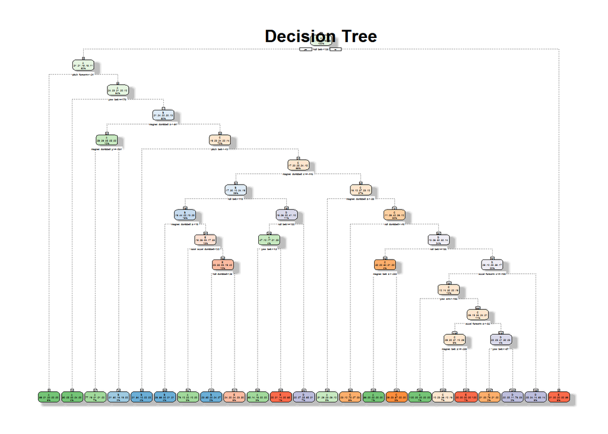

```r
fancyRpartPlot(fitDT, main="Decision Tree", sub="")
```

And the confusion matrix as follows.

```r
predictionDT <- predict(fitDT, validation, type = "class")
confusionMatrix(predictionDT, validation$classe)
```

```
## Confusion Matrix and Statistics
##
##           Reference
## Prediction    A    B    C    D    E
##          A 1252  170   51   44   35
##          B   26  509   36   44   21
##          C   58  132  610   69   92
##          D   35   55  134  551   65
##          E   24   83   24   96  688
##
## Overall Statistics
##
##                Accuracy : 0.7361
##                  95% CI : (0.7236, 0.7484)
##     No Information Rate : 0.2845
##     P-Value [Acc > NIR] : < 2.2e-16
##
##                   Kappa : 0.6653
##  Mcnemar's Test P-Value : < 2.2e-16
##
## Statistics by Class:
##
##                      Class: A Class: B Class: C Class: D Class: E
## Sensitivity            0.8975   0.5364   0.7135   0.6853   0.7636
## Specificity            0.9145   0.9679   0.9133   0.9295   0.9433
## Pos Pred Value         0.8067   0.8003   0.6348   0.6560   0.7519
## Neg Pred Value         0.9573   0.8969   0.9379   0.9377   0.9466
## Prevalence             0.2845   0.1935   0.1743   0.1639   0.1837
## Detection Rate         0.2553   0.1038   0.1244   0.1124   0.1403
## Detection Prevalence   0.3165   0.1297   0.1960   0.1713   0.1866
## Balanced Accuracy      0.9060   0.7521   0.8134   0.8074   0.8534
```

### Stochastic Gradient Boosting

The confusion matrix for the Stochastic Gradient Boosting model is as follows.

```r
predictionGBM <- predict(fitGBM, validation)
confusionMatrix(predictionGBM, validation$classe)
```

```
## Confusion Matrix and Statistics
##
##           Reference
## Prediction    A    B    C    D    E
##          A 1375   19    0    0    4
##          B   14  909   26    2    5
##          C    4   20  821   23    9
##          D    1    1    5  776   13
##          E    1    0    3    3  870
##
## Overall Statistics
##
##                Accuracy : 0.9688
##                  95% CI : (0.9635, 0.9735)
##     No Information Rate : 0.2845
##     P-Value [Acc > NIR] : < 2.2e-16
##
##                   Kappa : 0.9605
##  Mcnemar's Test P-Value : 0.0001522
##
## Statistics by Class:
##
##                      Class: A Class: B Class: C Class: D Class: E
## Sensitivity            0.9857   0.9579   0.9602   0.9652   0.9656
## Specificity            0.9934   0.9881   0.9862   0.9951   0.9983
## Pos Pred Value         0.9835   0.9508   0.9361   0.9749   0.9920
## Neg Pred Value         0.9943   0.9899   0.9916   0.9932   0.9923
## Prevalence             0.2845   0.1935   0.1743   0.1639   0.1837
## Detection Rate         0.2804   0.1854   0.1674   0.1582   0.1774
## Detection Prevalence   0.2851   0.1949   0.1788   0.1623   0.1788
## Balanced Accuracy      0.9896   0.9730   0.9732   0.9801   0.9819
```

### Random Forest

The confusion matrix for the random forest model is as follows.

```r
predictionRF <- predict(fitRF, validation)
confusionMatrix(predictionRF, validation$classe)
```

```
## Confusion Matrix and Statistics
##
##           Reference
## Prediction    A    B    C    D    E
##          A 1391    5    0    0    0
##          B    4  942    5    0    0
##          C    0    2  849   19    0
##          D    0    0    1  784    0
##          E    0    0    0    1  901
##
## Overall Statistics
##
##                Accuracy : 0.9925
##                  95% CI : (0.9896, 0.9947)
##     No Information Rate : 0.2845
##     P-Value [Acc > NIR] : < 2.2e-16
##
##                   Kappa : 0.9905
##  Mcnemar's Test P-Value : NA
##
## Statistics by Class:
##
##                      Class: A Class: B Class: C Class: D Class: E
## Sensitivity            0.9971   0.9926   0.9930   0.9751   1.0000
## Specificity            0.9986   0.9977   0.9948   0.9998   0.9998
## Pos Pred Value         0.9964   0.9905   0.9759   0.9987   0.9989
## Neg Pred Value         0.9989   0.9982   0.9985   0.9951   1.0000
## Prevalence             0.2845   0.1935   0.1743   0.1639   0.1837
## Detection Rate         0.2836   0.1921   0.1731   0.1599   0.1837
## Detection Prevalence   0.2847   0.1939   0.1774   0.1601   0.1839
## Balanced Accuracy      0.9979   0.9952   0.9939   0.9874   0.9999
```

### Combination of the models

A combination of the three models resulted in the following confusion matrix.

```r
predDF <- data.frame(predictionDT, predictionGBM, predictionRF, validation$classe)
combModFit <- train(validation.classe ~ ., method = "rf", data = predDF)
combPred <- predict(combModFit, predDF)
confusionMatrix(combPred, validation$classe)
```

```
## Confusion Matrix and Statistics
##
##           Reference
## Prediction    A    B    C    D    E
##          A 1391    5    0    0    0
##          B    4  942    5    0    0
##          C    0    2  848   12    0
##          D    0    0    2  791    0
##          E    0    0    0    1  901
##
## Overall Statistics
##
##                Accuracy : 0.9937
##                  95% CI : (0.991, 0.9957)
##     No Information Rate : 0.2845
##     P-Value [Acc > NIR] : < 2.2e-16
##
##                   Kappa : 0.992
##  Mcnemar's Test P-Value : NA
##
## Statistics by Class:
##
##                      Class: A Class: B Class: C Class: D Class: E
## Sensitivity            0.9971   0.9926   0.9918   0.9838   1.0000
## Specificity            0.9986   0.9977   0.9965   0.9995   0.9998
## Pos Pred Value         0.9964   0.9905   0.9838   0.9975   0.9989
## Neg Pred Value         0.9989   0.9982   0.9983   0.9968   1.0000
## Prevalence             0.2845   0.1935   0.1743   0.1639   0.1837
## Detection Rate         0.2836   0.1921   0.1729   0.1613   0.1837
## Detection Prevalence   0.2847   0.1939   0.1758   0.1617   0.1839
## Balanced Accuracy      0.9979   0.9952   0.9942   0.9917   0.9999
```

### Comparison of the models

The accuracy of the models was as follows:

```r
paste("Decision Tree:                  ",confusionMatrix(predictionDT, validation$classe)$overall[[1]],sep="")
```

```
## [1] "Decision Tree:                  0.736133768352365"
```

```r
paste("Stochastic Gradient Boosting:   ",confusionMatrix(predictionGBM, validation$classe)$overall[[1]],sep="")
```

```
## [1] "Stochastic Gradient Boosting:   0.968800978792822"
```

```r
paste("Random Forest:                  ",confusionMatrix(predictionRF, validation$classe)$overall[[1]],sep="")
```

```
## [1] "Random Forest:                  0.992455138662316"
```

```r
paste("Combination of three models:    ",confusionMatrix(combPred, validation$classe)$overall[[1]],sep="")
```

```
## [1] "Combination of three models:    0.993678629690049"
```

### Predicting the test set

The prediction classe of the 20 test cases was as follows:

```r
predictionRF <- predict(fitRF, testing.csv)
predictionRF
```

```
##  [1] B A B A A E D B A A B C B A E E A B B B
## Levels: A B C D E
```

```r
writeFiles = function(x){
  n = length(x)
  for(i in 1:n){
    filename = paste0("problem_id_",i,".txt")
    write.table(x[i],file=filename,quote=FALSE,row.names=FALSE,col.names=FALSE)
  }
}
writeFiles(predictionRF)
```

## Discussion & Conclusion

The accuracy of the random forest model is very high, about 99%. This matches the outcome of the prediction of the test set, as these were all correctly classified.